# Practice Code: Day 4

Author

Constantin Manuel Bosancianu

Published

August 3, 2017

# 1 Introduction

```r
library(pacman)
p_load(readstata13, tidyverse, lmtest, MASS, car, texreg, knitr,
       kableExtra, magrittr, ggthemes, effects, interplot, zoo,
       splines, mgcv, visreg)

options(scipen = 8) # Avoid scientific notation for coefficients
```

```r
fun_cent <- function(x) {
    x - mean(x, na.rm = TRUE)
}
```

Today’s practice will be different, in some respects, than the sessions from past days. Our usual *modus operandi* has been to faithfully follow the concepts and analyses discussed in the lecture part by means of code.

However, today that pattern would not be very useful. This is because almost no current day analysis focuses on a nonparametric estimate of the effect of a single variable on the outcome. Whan we want to see is multivariate analyses. This is why we start with a very quick coverage of the concepts discussed in the first session, and then move to an practical presentation of how smoothers and splines are used in multivariate specifications called semiparametric models.

Because the goal is to get to semiparametric specifications as quickly as possible, I continue with the same example I used in the first session: support for challengers in House elections in 1992.

```r
df_jacob <- read.dta13(file = "../02-data/09-jacob.dta",
                       convert.factors = FALSE)
```

The relationship we’re interested in describing.

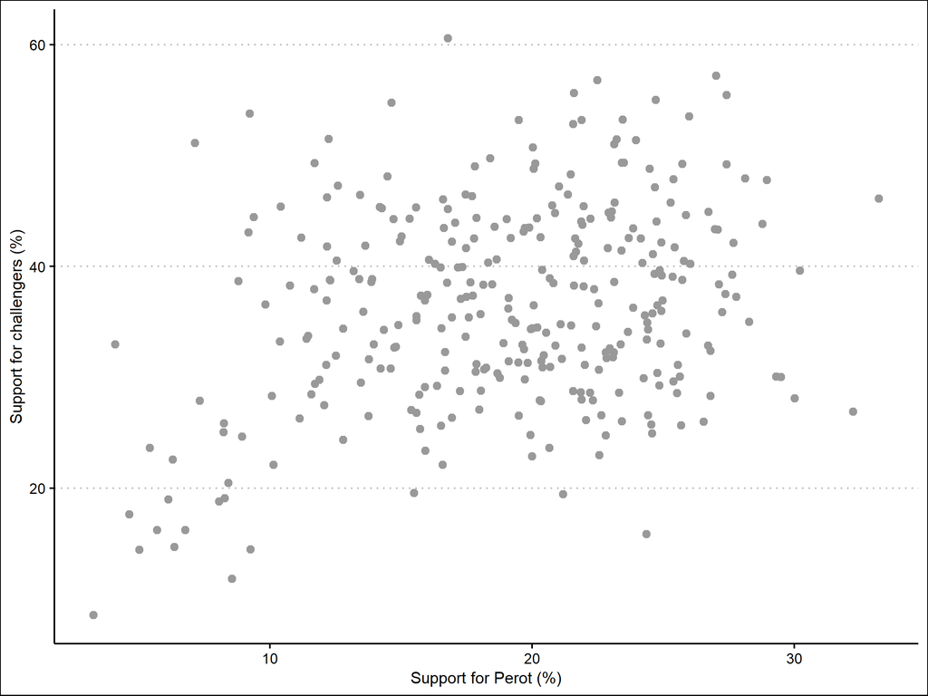

```r
ggplot(data = df_jacob,
       aes(x = perotvote,
           y = chal_vote)) +
    geom_point(size = 2,
               color = "gray60") +
    labs(x = "Support for Perot (%)",
         y = "Support for challengers (%)") +
    theme_clean()
```

# 2 Local Polynomial Regression (LPR)

```r
df_lpr <- df_jacob %>%
    dplyr::select(chal_vote, perotvote) %>%
    arrange(perotvote)
```

Doing a moving average smoother usually involves setting a window width, and then running a `for()` loop across most of the `X` variable, so as to compute the moving average. While that is fine for 312 observations, it would be terribly inefficient (not in the statistical sense of the word) for larger data sets. As a general rule, `for()` loops are not a good idea in **R**. This is why we will use a dedicated function for this in the `zoo` package: `rollmean()`.

```r
yhat <- rollmean(df_lpr$chal_vote, # predictor variable
                 k = 51) # window width
```

The problem is that for the first 25 and last 25 values, a moving average cannot be computed, as the window width would be smaller than 51. So, if we want to store the `yhat` in the original data set, we have to use a small hack.

```r
df_lpr$yhat <- c(rep(NA, times = 25), # NA padding in the beginning
                 yhat, # actual values
                 rep(NA, times = 25)) # NA padding at the end

df_lpr %>%
    mutate(pos = 1:n()) %>%
    relocate(pos) %>%
    slice(c(1:10, 20:30, 40:50)) %>%
    kable(digits = 3,
          caption = "Rolling mean results",
          col.names = c("Position", "Challenger %", "Perot %", "Yhat"),
          caption.above = TRUE) %>%
    kable_styling(full_width = TRUE)
```

Rolling mean results

| Position | Challenger % | Perot % | Yhat |
| --- | --- | --- | --- |
| 1 | 8.557 | 3.273 | NA |
| 2 | 32.959 | 4.099 | NA |
| 3 | 17.620 | 4.630 | NA |
| 4 | 14.410 | 5.017 | NA |
| 5 | 23.623 | 5.411 | NA |
| 6 | 16.218 | 5.687 | NA |
| 7 | 18.960 | 6.124 | NA |
| 8 | 22.569 | 6.291 | NA |
| 9 | 14.696 | 6.357 | NA |
| 10 | 16.202 | 6.766 | NA |
| 20 | 24.639 | 8.936 | NA |
| 21 | 43.050 | 9.179 | NA |
| 22 | 53.766 | 9.220 | NA |
| 23 | 14.471 | 9.259 | NA |
| 24 | 44.448 | 9.381 | NA |
| 25 | 36.549 | 9.833 | NA |
| 26 | 28.295 | 10.074 | 31.099 |
| 27 | 22.089 | 10.132 | 31.408 |
| 28 | 33.222 | 10.379 | 31.538 |
| 29 | 45.381 | 10.417 | 31.954 |
| 30 | 38.243 | 10.759 | 32.582 |
| 40 | 27.474 | 12.063 | 34.872 |
| 41 | 31.094 | 12.153 | 35.252 |
| 42 | 36.913 | 12.156 | 35.550 |
| 43 | 41.793 | 12.182 | 36.092 |
| 44 | 46.210 | 12.182 | 36.464 |
| 45 | 51.468 | 12.241 | 36.780 |
| 46 | 38.783 | 12.278 | 37.164 |
| 47 | 38.746 | 12.296 | 36.961 |
| 48 | 31.943 | 12.517 | 36.549 |
| 49 | 40.524 | 12.539 | 36.946 |
| 50 | 47.261 | 12.586 | 36.903 |

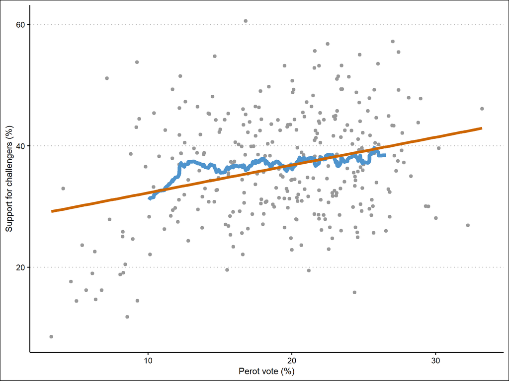

```r
ggplot(data = df_lpr,
       aes(x = perotvote,
           y = chal_vote)) +
    geom_point(size = 1.5,
               color = "grey60") +
    labs(x = "Perot vote (%)",
         y = "Support for challengers (%)") +
    theme_clean() +
    geom_line(aes(x = perotvote,
                  y = yhat),
              linewidth = 2,
              color = "steelblue3") +
    geom_smooth(method = "lm",
                se = FALSE,
                linewidth = 1.5,
                color = "darkorange3")
```

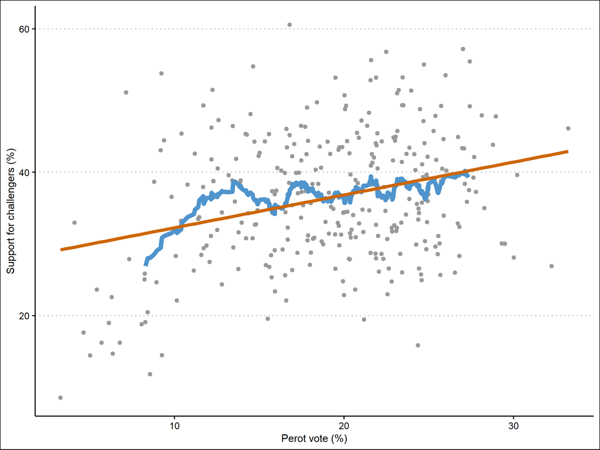

```r
kwin <- 31
df_lpr$yhat2 <- c(rep(NA, times = (kwin - 1) / 2), # NA padding in the beginning
                  rollmean(df_lpr$chal_vote, k = kwin), # actual values
                  rep(NA, times = (kwin - 1) / 2)) # NA padding at the end

ggplot(data = df_lpr,
       aes(x = perotvote,
           y = chal_vote)) +
    geom_point(size = 1.5,
               color = "grey60") +
    labs(x = "Perot vote (%)",
         y = "Support for challengers (%)") +
    theme_clean() +
    geom_line(aes(x = perotvote,
                  y = yhat2),
              linewidth = 2,
              color = "steelblue3") +
    geom_smooth(method = "lm",
                se = FALSE,
                linewidth = 1.5,
                color = "darkorange3")
```

It’s pretty clear that with a smaller window, the estimates of the mean become more variable. And if we increase the window?

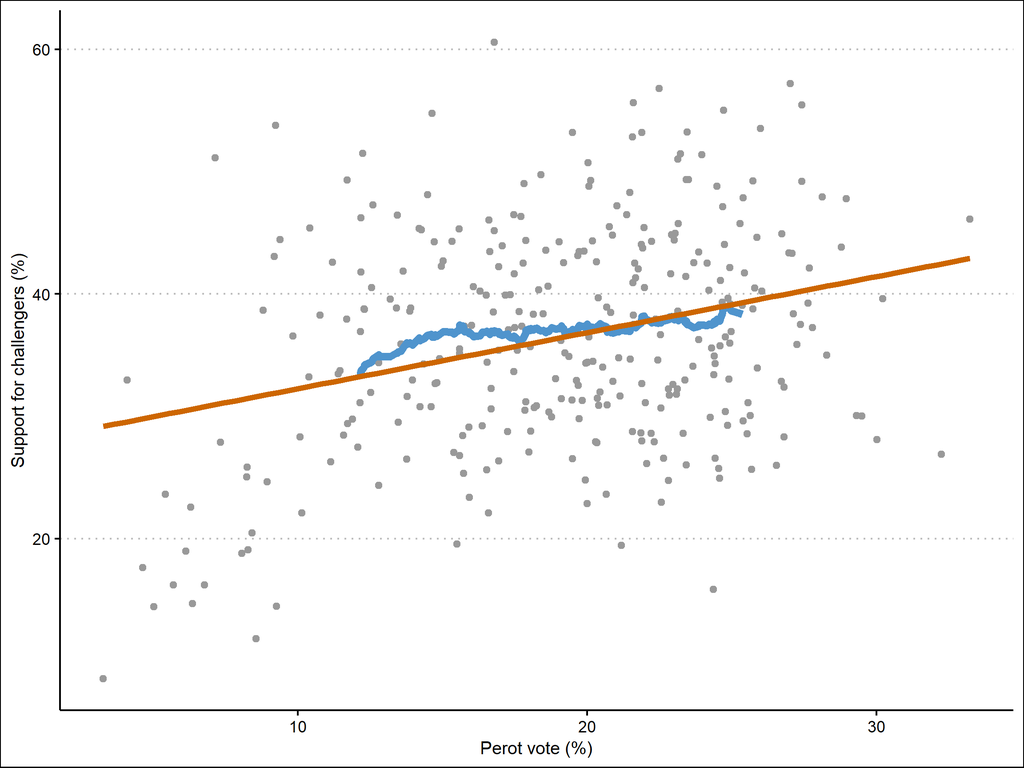

```r
kwin <- 81
df_lpr$yhat3 <- c(rep(NA, times = (kwin - 1) / 2), # NA padding in the beginning
                  rollmean(df_lpr$chal_vote, k = kwin), # actual values
                  rep(NA, times = (kwin - 1) / 2)) # NA padding at the end

ggplot(data = df_lpr,
       aes(x = perotvote,
           y = chal_vote)) +
    geom_point(size = 1.5,
               color = "grey60") +
    labs(x = "Perot vote (%)",
         y = "Support for challengers (%)") +
    theme_clean() +
    geom_line(aes(x = perotvote,
                  y = yhat3),
              linewidth = 2,
              color = "steelblue3") +
    geom_smooth(method = "lm",
                se = FALSE,
                linewidth = 1.5,
                color = "darkorange3")
```

```r
rm(df_lpr)
```

# 3 Kernel smoothing

This adds a weight and a weighting rule to the standard moving average approach. The quick solution to this is the `ksmooth()` function from base **R**.

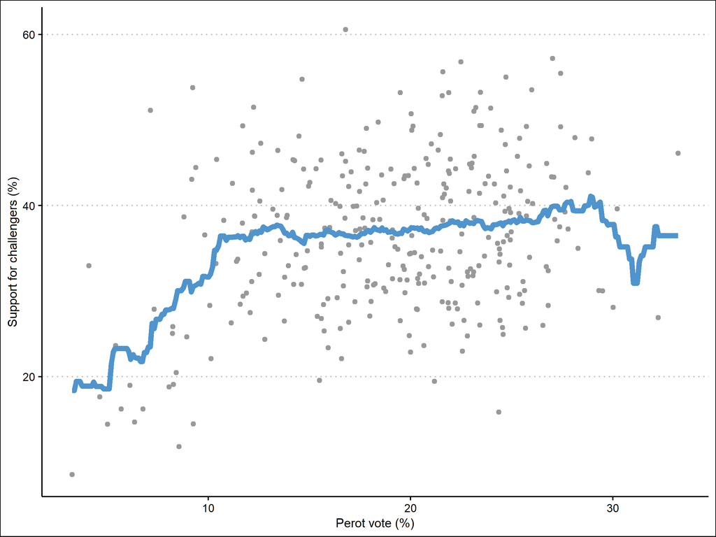

```r
kern <- ksmooth(x = df_jacob$perotvote,
                y = df_jacob$chal_vote,
                bandwidth = 4)

ggplot(data = df_jacob,
       aes(x = perotvote,
           y = chal_vote)) +
    geom_point(size = 1.5,
               color = "gray60") +
    labs(x = "Perot vote (%)",
         y = "Support for challengers (%)") +
    theme_clean() +
    geom_line(data = NULL,
              aes(x = as.vector(kern$x),
                  y = as.vector(kern$y)),
              linewidth = 2,
              color = "steelblue3")
```

What if we increase the bandwidth to 10?

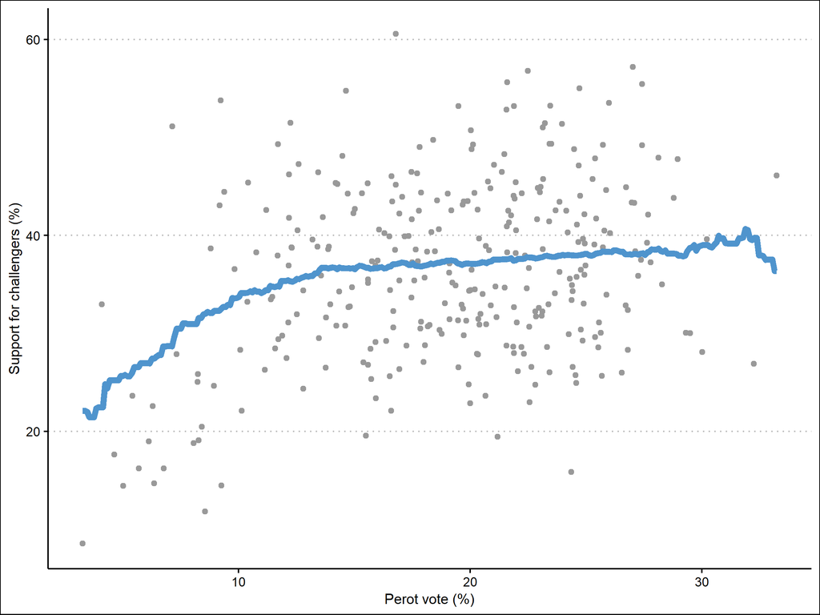

```r
kern <- ksmooth(x = df_jacob$perotvote,
                y = df_jacob$chal_vote,
                bandwidth = 10)

ggplot(data = df_jacob,
       aes(x = perotvote,
           y = chal_vote)) +
    geom_point(size = 1.5,
               color = "gray60") +
    labs(x = "Perot vote (%)",
         y = "Support for challengers (%)") +
    theme_clean() +
    geom_line(data = NULL,
              aes(x = kern[[1]],
                  y = kern[[2]]),
              linewidth = 2,
              color = "steelblue3")
```

# 4 Polynomial specifications

Moving average approaches or kernel smoothers don’t really rely on a statistical specification: they simply compute an average. This has obvious computational benefits, as an average is pretty fast to compute. Nowadays, though, we can easily turn to a regression, as that has slightly more appealing properties.

First, the *loess*.

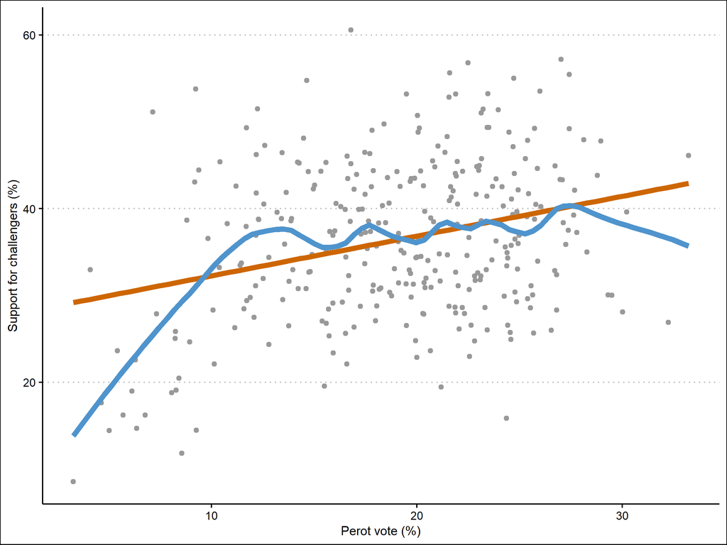

```r
ggplot(data = df_jacob,
       aes(x = perotvote,
           y = chal_vote)) +
    geom_point(size = 1.5,
               color = "gray60") +
    labs(x = "Perot vote (%)",
         y = "Support for challengers (%)") +
    theme_clean() +
    geom_smooth(method = "lm",
                se = FALSE,
                linewidth = 2,
                color = "darkorange3") +
    geom_smooth(method = "loess",
                se = FALSE,
                span = 0.3,
                linewidth = 2,
                color = "steelblue3")
```

However, if you want finer control than what is implemented through the `geom_smooth()` function in `ggplot2`, you can use the `loess()` function.

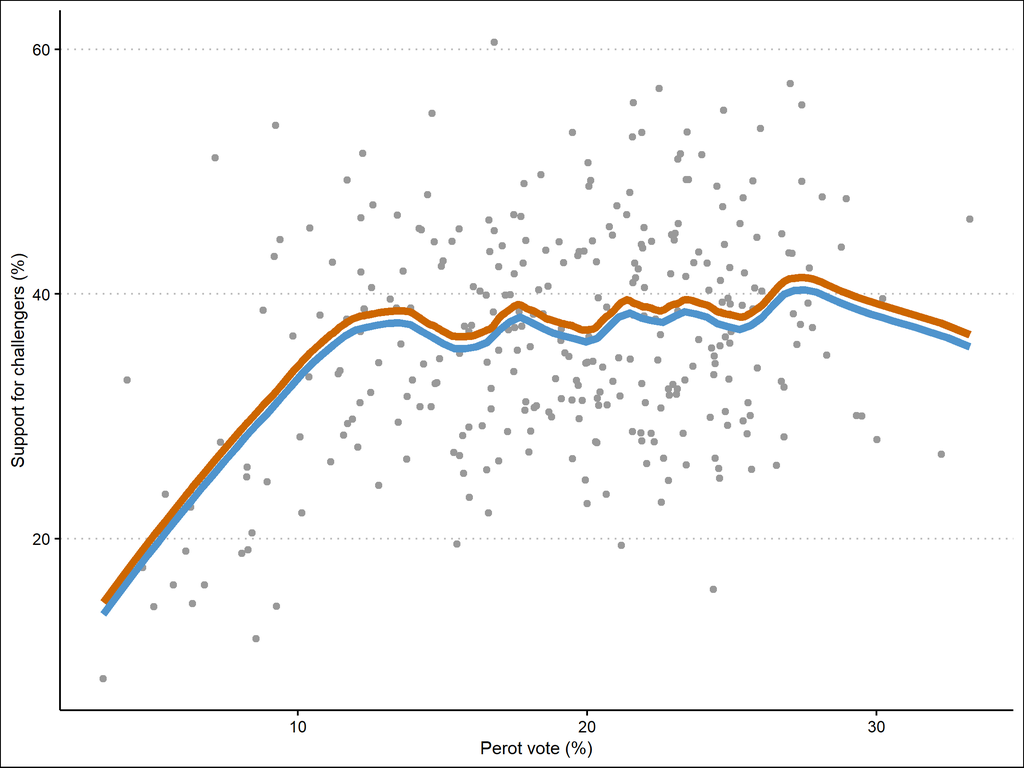

```r
lfit1 <- loess(chal_vote ~ perotvote,
               data = df_jacob,
               span = 0.3)

ggplot(data = df_jacob,
       aes(x = perotvote,
           y = chal_vote)) +
    geom_point(size = 1.5,
               color = "gray60") +
    labs(x = "Perot vote (%)",
         y = "Support for challengers (%)") +
    theme_clean() +
    geom_smooth(method = "loess",
                se = FALSE,
                span = 0.3,
                linewidth = 2,
                color = "steelblue3") +
    geom_line(data = NULL,
              aes(x = df_jacob$perotvote,
                  y = lfit1$fitted + 1),
              linewidth = 2,
              color = "darkorange3")
```

The plot above just shows you that if you do it from within `geom_smooth()` or with the `loess()` function, it doesn’t make a difference.[^1]

<sup>1</sup> I added `+ 1` to the fitted values so that the orange line doesn’t perfectly overlap the blue one.

`loess()` can also do **LOWESS**, as long as you supply a column of weights (usually computed with the tricube kernel). However, there is also a dedicated function in the `stats` package, named `lowess()`.

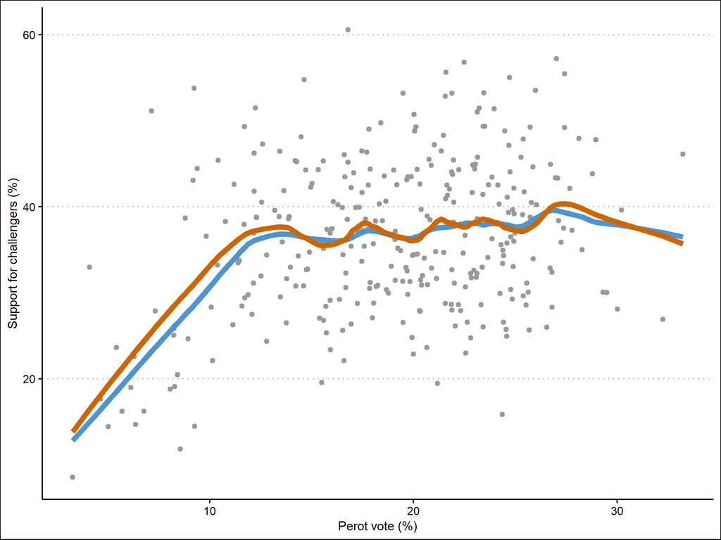

```r
lfit2 <- lowess(x = df_jacob$perotvote,
                y = df_jacob$chal_vote,
                f = 0.25)

ggplot(data = df_jacob,
       aes(x = perotvote,
           y = chal_vote)) +
    geom_point(size = 1.5,
               color = "gray60") +
    labs(x = "Perot vote (%)",
         y = "Support for challengers (%)") +
    theme_clean() +
    geom_line(data = NULL,
              aes(x = lfit2$x,
                  y = lfit2$y),
              linewidth = 2,
              color = "steelblue3") +
    geom_line(data = NULL,
              aes(x = df_jacob$perotvote,
                  y = lfit1$fitted),
              linewidth = 2,
              color = "darkorange3")
```

```r
rm(lfit2)
```

You can see that the differences between the two are really very small. In practice, most of the times, it will not matter if you use **LOESS** or **LOWESS**.

If you also want standard errors for the **LOESS** fit, that’s one extra line of code. If you want to, you can also supply a new data set to the function (if you do not, this function will rely on the original data).

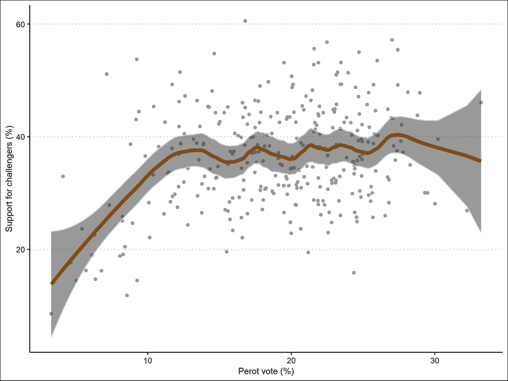

```r
pfit1 <- predict(lfit1, # LOESS object
                 se = TRUE) # standard errors should be computed

ggplot(data = df_jacob,
       aes(x = perotvote,
           y = chal_vote)) +
    geom_point(size = 1.5,
               color = "gray60") +
    labs(x = "Perot vote (%)",
         y = "Support for challengers (%)") +
    theme_clean() +
    geom_line(data = NULL,
              aes(x = df_jacob$perotvote,
                  y = lfit1$fitted),
              linewidth = 2,
              color = "darkorange3") +
    geom_ribbon(data = NULL,
                aes(ymin = pfit1$fit - 1.96 * pfit1$se.fit,
                    ymax = pfit1$fit + 1.96 * pfit1$se.fit),
                alpha = 0.5,
                color = "grey80")
```

You can also test a whether the polynomial specification you’ve estimated fits the data better than a standard linear model. Here, though, because the model objects are of a different type, the test will have to be done manually.[^2]

<sup>2</sup> Part of the code presented below is adapted from Keele (2008).

We begin by first running two specifications: nonparametric and parametric linear.

```r
mod.nonpar <- loess(chal_vote ~ perotvote,
                    span = .5, # span
                    degree = 2, # maximum degree of the polynomial
                    data = df_jacob)

mod.par <- lm(chal_vote ~ perotvote,
              data = df_jacob)
```

We then compute a few quantities of interest which will go into the statistical test.

```r
# Residual sum of squares for loess fit
RSS.npar <- sum(residuals(mod.nonpar) ^ 2)
#Residual sum of squares for linear model
RSS.lm <- sum(residuals(mod.par) ^ 2)

mod.df <- mod.nonpar$trace
res.df <- mod.nonpar$n - mod.df
```

Finally, we compute the test statistic.[^3]

<sup>3</sup> **2** is used in the formulas because a simple linear regression only estimates 2 parameters: an intercept and a slope).

```r
f.2 <- ((RSS.lm - RSS.npar)/(mod.df - 2)) / (RSS.npar/(res.df))
f.2
```

```
[1] 4.742065
```

```r
# P-Value
1 - (pf(f.2, (mod.df - 2) , res.df, lower.tail=TRUE))
```

```
[1] 0.0001192689
```

# 5 Splines

We work here with the functions available in the `splines` package.

```r
mod.bspline <- lm(chal_vote ~ bs(perotvote, df = 7, intercept = TRUE),
                  data = df_jacob)
mod.nspline <- lm(chal_vote ~ ns(perotvote, df = 5, intercept = TRUE),
                  data = df_jacob)

summary(mod.nspline)
```

```
Call:
lm(formula = chal_vote ~ ns(perotvote, df = 5, intercept = TRUE),
    data = df_jacob)

Residuals:
     Min       1Q   Median       3Q      Max
-22.7054  -6.0490  -0.6333   6.0192  25.5719

Coefficients: (1 not defined because of singularities)
                                         Estimate Std. Error t value  Pr(>|t|)
(Intercept)                                74.945     16.993   4.410 0.0000143
ns(perotvote, df = 5, intercept = TRUE)1  -19.110     13.249  -1.442   0.15021
ns(perotvote, df = 5, intercept = TRUE)2  -39.698     16.690  -2.379   0.01799
ns(perotvote, df = 5, intercept = TRUE)3   -6.395      9.075  -0.705   0.48154
ns(perotvote, df = 5, intercept = TRUE)4 -103.024     37.312  -2.761   0.00611
ns(perotvote, df = 5, intercept = TRUE)5       NA         NA      NA        NA

(Intercept)                              ***
ns(perotvote, df = 5, intercept = TRUE)1
ns(perotvote, df = 5, intercept = TRUE)2 *
ns(perotvote, df = 5, intercept = TRUE)3
ns(perotvote, df = 5, intercept = TRUE)4 **
ns(perotvote, df = 5, intercept = TRUE)5
---
Signif. codes:  0 '***' 0.001 '**' 0.01 '*' 0.05 '.' 0.1 ' ' 1

Residual standard error: 8.4 on 307 degrees of freedom
Multiple R-squared:  0.1567,    Adjusted R-squared:  0.1457
F-statistic: 14.26 on 4 and 307 DF,  p-value: 0.0000000001091
```

For both functions it’s the same number of knots, but the `bs()` function computes $knots = df - 3$, while `ns()` computes them as `knots = df - 1`.

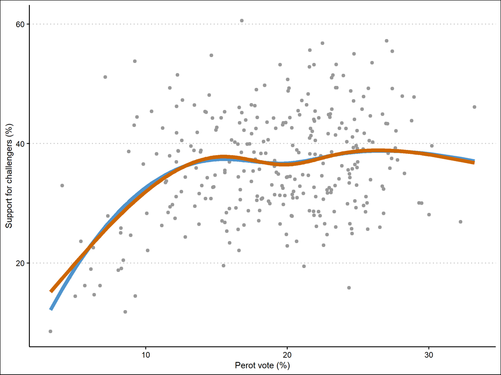

```r
sfit.1 <- predict(mod.bspline) # use the original data for prediction
sfit.2 <- predict(mod.nspline)

ggplot(data = df_jacob,
       aes(x = perotvote,
           y = chal_vote)) +
    geom_point(size = 1.5,
               color = "gray60") +
    labs(x = "Perot vote (%)",
         y = "Support for challengers (%)") +
    theme_clean() +
    geom_line(data = NULL,
              aes(x = df_jacob$perotvote,
                  y = sfit.1),
              linewidth = 2,
              color = "steelblue3") +
    geom_line(data = NULL,
              aes(x = df_jacob$perotvote,
                  y = sfit.2),
              linewidth = 2,
              color = "darkorange3")
```

You can obtain penalized (smoothing) splines with the `smooth.spline()` function from the same `splines` package.[^4]

<sup>4</sup> There should be no `NA`s in either `X` or `Y` for the function to run.

```r
df_smooth1 <- smooth.spline(x = df_jacob$perotvote,
                            y = df_jacob$chal_vote,
                            spar = 0.1,
                            nknots = 4)
```

`spar` stands for “smoothing parameter” ($\lambda$ will be a function of this parameter).

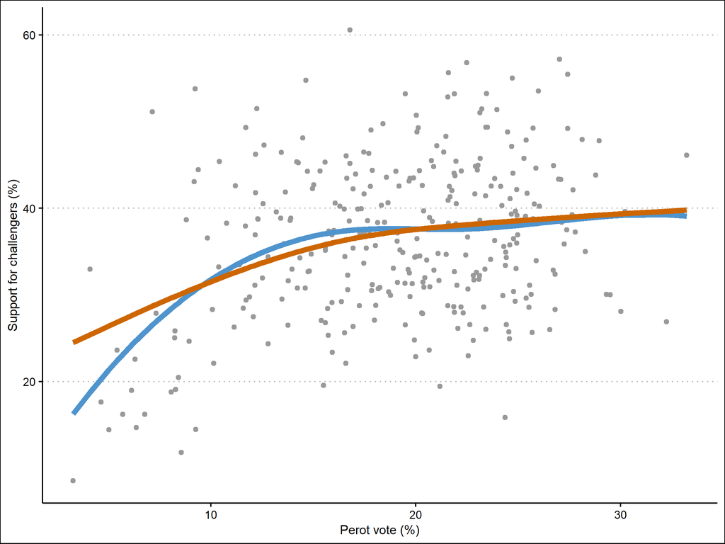

```r
df_smooth2 <- smooth.spline(x = df_jacob$perotvote,
                            y = df_jacob$chal_vote,
                            spar = 0.3,
                            nknots = 4)

ggplot(data = df_jacob,
       aes(x = perotvote,
           y = chal_vote)) +
    geom_point(size = 1.5,
               color = "gray60") +
    labs(x = "Perot vote (%)",
         y = "Support for challengers (%)") +
    theme_clean() +
    geom_line(data = NULL,
              aes(x = df_smooth1$x,
                  y = df_smooth1$y),
              linewidth = 2,
              color = "steelblue3") +
    geom_line(data = NULL,
              aes(x = df_smooth2$x,
                  y = df_smooth2$y),
              linewidth = 2,
              color = "darkorange3")
```

Increasing the span clearly makes a difference: higher values of the span produce a smoother fit, at the cost of potential bias in the estimate of the relationship.

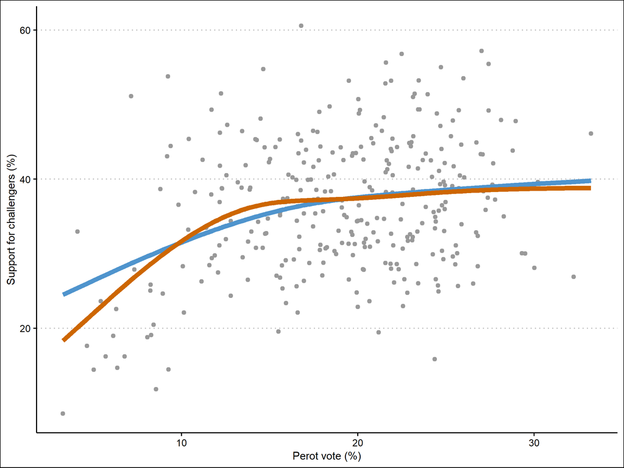

```r
df_smooth3 <- smooth.spline(x = df_jacob$perotvote,
                            y = df_jacob$chal_vote,
                            spar = 0.3,
                            nknots = 6)

ggplot(data = df_jacob,
       aes(x = perotvote,
           y = chal_vote)) +
    geom_point(size = 1.5,
               color = "gray60") +
    labs(x = "Perot vote (%)",
         y = "Support for challengers (%)") +
    theme_clean() +
    geom_line(data = NULL,
              aes(x = df_smooth2$x,
                  y = df_smooth2$y),
              linewidth = 2,
              color = "steelblue3") +
    geom_line(data = NULL,
              aes(x = df_smooth3$x,
                  y = df_smooth3$y),
              linewidth = 2,
              color = "darkorange3")
```

```r
rm(df_smooth1, df_smooth2, df_smooth3)
```

Both number of knots and smoothing parameter control the smoothness of the estimated relationship between the two variables.

# 6 Semiparametric models

In most social science applications, though, we don’t deal with bivariate relationships. What we would need is a way to estimate both linear relationships, as well as nonlinear ones, as part of the same model. Semiparametric models are a way to achieve this.

An nice introduction into semiparametric specifications are provided by additive models. These estimate separately, with a smoothing spline, the link between multiple predictors and the the outcome variable. In a sense we have: $Y = \alpha + f_1(X_1) + f_2(X_2)+ \dots + f_k(X_k)$, and each of these `f()` functions are estimated with smoothers.

```r
gam1 <- gam(chal_vote ~ s(perotvote, bs = "cr") +
                s(checks_raw, bs = "cr"),
            data = df_jacob)
summary(gam1)
```

```
Family: gaussian
Link function: identity

Formula:
chal_vote ~ s(perotvote, bs = "cr") + s(checks_raw, bs = "cr")

Parametric coefficients:
            Estimate Std. Error t value Pr(>|t|)
(Intercept)  36.4159     0.4685   77.72   <2e-16 ***
---
Signif. codes:  0 '***' 0.001 '**' 0.01 '*' 0.05 '.' 0.1 ' ' 1

Approximate significance of smooth terms:
                edf Ref.df      F p-value
s(perotvote)  4.047  4.969 12.171  <2e-16 ***
s(checks_raw) 2.450  2.882  3.643  0.0235 *
---
Signif. codes:  0 '***' 0.001 '**' 0.01 '*' 0.05 '.' 0.1 ' ' 1

R-sq.(adj) =  0.171   Deviance explained = 18.8%
GCV = 70.176  Scale est. = 68.49     n = 312
```

`gam()` will estimate the additive model, but we need to specify for each predictor whether we want a simple smoother (`s()`), and what type of smoother that should be (`cr` = *cubic regression*).

For each of the terms in the model, you can obtain a graphical assessment of its effect on the dependent variable.

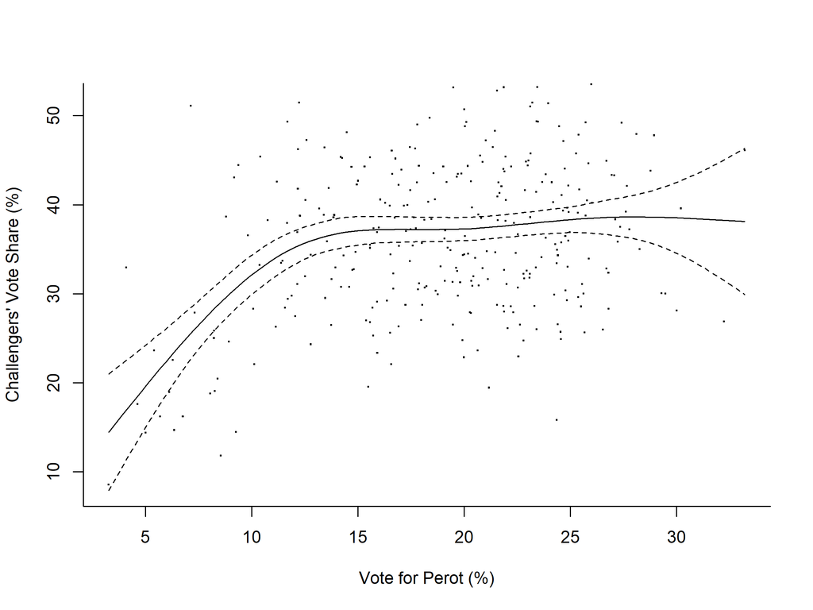

```r
plot(gam1, select = 1,
     rug = FALSE, se = TRUE,
     ylab = "Challengers' Vote Share (%)",
     xlab = "Vote for Perot (%)",
     residual = FALSE, bty = "l",
     shift = 36.4159)
points(df_jacob$perotvote,
       df_jacob$chal_vote,
       pch = ".", cex = 1.75)
```

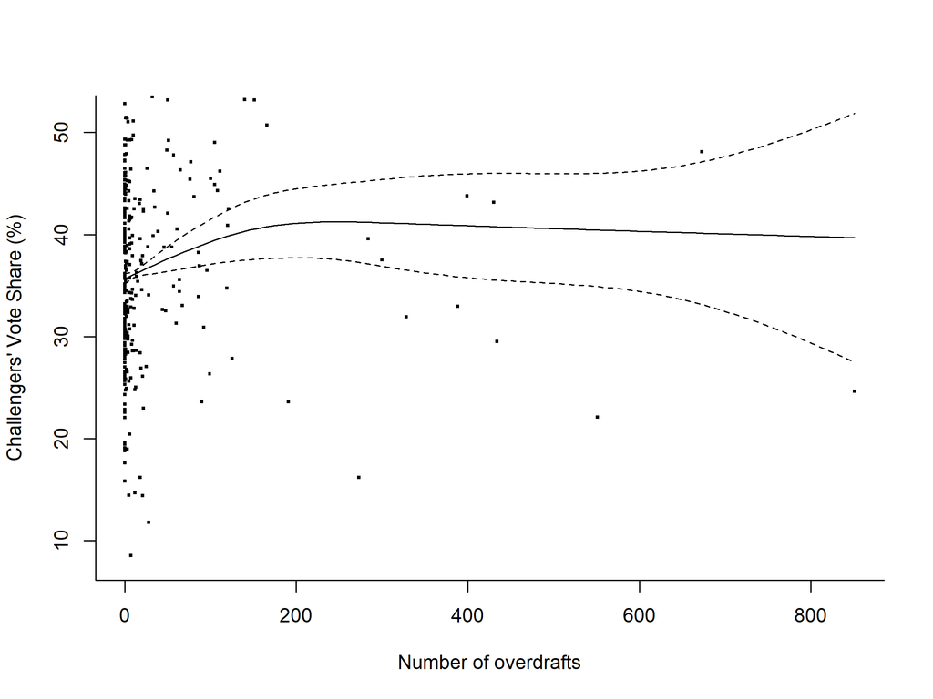

```r
plot(gam1, select = 2,
     rug = FALSE, se = TRUE,
     ylab = "Challengers' Vote Share (%)",
     xlab = "Number of overdrafts",
     residual = FALSE, bty = "l",
     shift = 36.4159)
points(df_jacob$checks_raw,
       df_jacob$chal_vote,
       pch = ".", cex = 2.75)
```

If you’re not happy with the default plotting style, you can use a custom function to extract the needed quantities from the `gam` output object, and feed them into `ggplot2` functions.

```r
fun_gg_gam <- function(model, type = "conditional", res = FALSE,
                       col.line = "#CD6600", col.point = "#999999",
                       size.line = 1, size.point = 1) {
  require(visreg)
  require(plyr)
  plotdata <- visreg(model, type = type, plot = FALSE)
  smooths <- ldply(plotdata, function(part)
    data.frame(Variable = part$meta$x,
               x = part$fit[[part$meta$x]],
               smooth = part$fit$visregFit,
               lower = part$fit$visregLwr,
               upper = part$fit$visregUpr))
  residuals <- ldply(plotdata, function(part)
    data.frame(Variable = part$meta$x,
               x = part$res[[part$meta$x]],
               y = part$res$visregRes))
  require(ggthemes)
  if (res)
    ggplot(smooths,
           aes(x, smooth)) +
        geom_line(col = col.line,
                  linewidth = size.line) +
        geom_line(aes(y = lower),
                  linetype="dashed",
                  col = col.line,
                  linewidth = size.line) +
        geom_line(aes(y = upper),
                  linetype = "dashed",
                  col = col.line,
                  linewidth = size.line) +
        geom_point(data = residuals,
                   aes(x, y),
                   col = col.point,
                   size = size.point) +
        facet_grid(. ~ Variable, scales = "free_x") +
        theme_clean()
  else
    ggplot(smooths,
           aes(x, smooth)) +
        geom_line(col = col.line,
                  linewidth = size.line) +
        geom_line(aes(y = lower),
                  linetype = "dashed",
                  col = col.line,
                  linewidth = size.line) +
        geom_line(aes(y = upper),
                  linetype = "dashed",
                  col = col.line,
                  linewidth = size.line) +
        facet_grid(. ~ Variable, scales = "free_x") +
        theme_clean()
  }
```